# Data Science and Analytics - Assigment

Βούτα - Παπαγεωργίου Αικατερίνη

28-06-2023

## Εισαγωγή

Σε αυτή την εργασία χρησιμοποιήθηκαν δεδομένα από την Παγκόσμια Τράπεζα και συγκεκριμένα δεδομένα που αφορούσαν την εκπαίδευση ([Education](https://data.worldbank.org/topic/education?end=2022&start=2000&view=chart)). Από αυτά διαχωρίσαμε και αξιοποιήσαμε στοιχεία για 22 Ευρωπαϊκές χώρες και για το διάστημα 2000 – 2022 . Πιο συγκεκριμένα τα δεδομένα αφορούν την ανεργία (**Unemployment.csv**) , την εισαγωγή παιδιών στην Δευτεροβάθμια εκπαίδευση (**School_Enrollment.csv**) καθώς και το συνόλου του πληθυσμού με ηλικίες 0 έως 14 έτη (**Population_014.csv**) και 15 έως 64 έτη (**Population_15_64.csv**).

## Εισαγωγή δεδομένων

Αρχικά έγινε φόρτωση όλων των απαραίτητων βιβλιοθηκών, καθώς και επεξεργασία των δεδομένων προκειμένου τα δεδομένα στα οποία θα καταλήξουμε να είναι tidy.

## Δημιουργια Γραφηματων

Στη συνέχεια αξιοποιήσαμε τα δεδομένα του αρχείου Unemployment προκειμένου να δημιουργήσουμε ένα scatterplot στο οποίο θα απεικονίζονται τα ποσοστά ανεργίας στην Ελλάδα για συγκεκριμένο χρονικό διάστημα.

### **Ποσοστά ανεργίας στην Ελλάδα απο το 2000 εως το 2022**

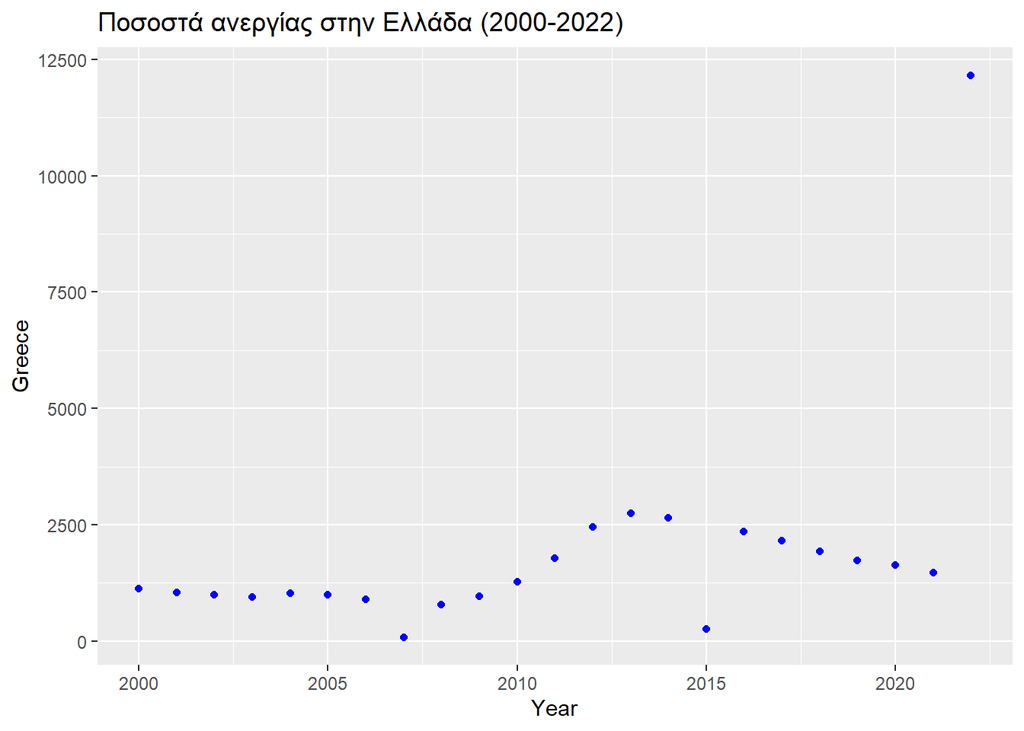

Έπειτα συνδυάσαμε τα δεδομένα των πινάκων που αναφέρονται στα πληθυσμιακά στοιχεία παιδιών και ενήλικων προκειμένου να παρουσιάσουμε ένα ιστόγραμμα με τον συνολικό πληθυσμό της Ελλάδας ανά τα έτη.

### **Συνολικός Πλυθησμός Ελλάδας**

```
##   Year     Greece
## 1 2000 8309992681
## 2 2001 8280060709
## 3 2002 2127458086
## 4 2003 8217832765
## 5 2004 8189197829
## 6 2005 6877965591
```

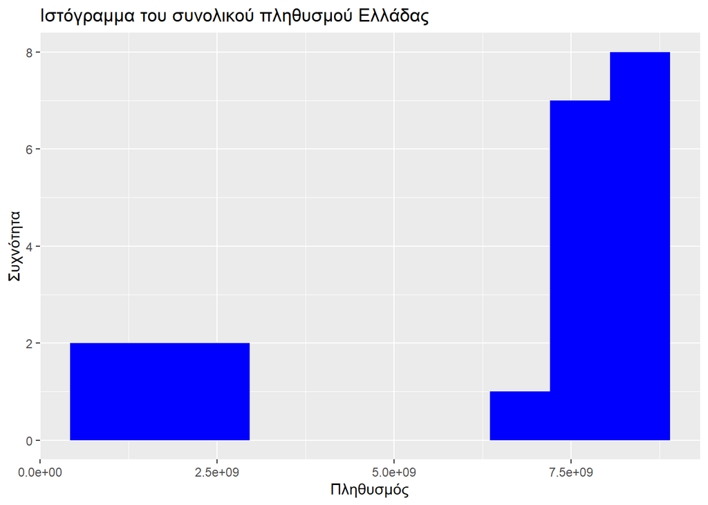

Γενικές πληροφορίες αντλήθηκαν από την [ιστοσελιδα](https://el.wikipedia.org/wiki/%CE%94%CE%B7%CE%BC%CE%BF%CE%B3%CF%81%CE%B1%CF%86%CE%AF%CE%B1_%CF%84%CE%B7%CF%82_%CE%95%CE%BB%CE%BB%CE%AC%CE%B4%CE%B1%CF%82).

Τέλος, επεξεργαστήκαμε τα δεδομένα του πίνακα **School_Enrollment** ωστε να μπορέσουμε να προβάλουμε ένα boxplot με τις Εγγραφές στην Δευτεροβάθμια Εκπαίδευση ανά χωρά για το διάστημα 2000 - 2022

### **Εγγραφες στη Δευτεροβαθμια Εκπαιδευση ανα χωρα**

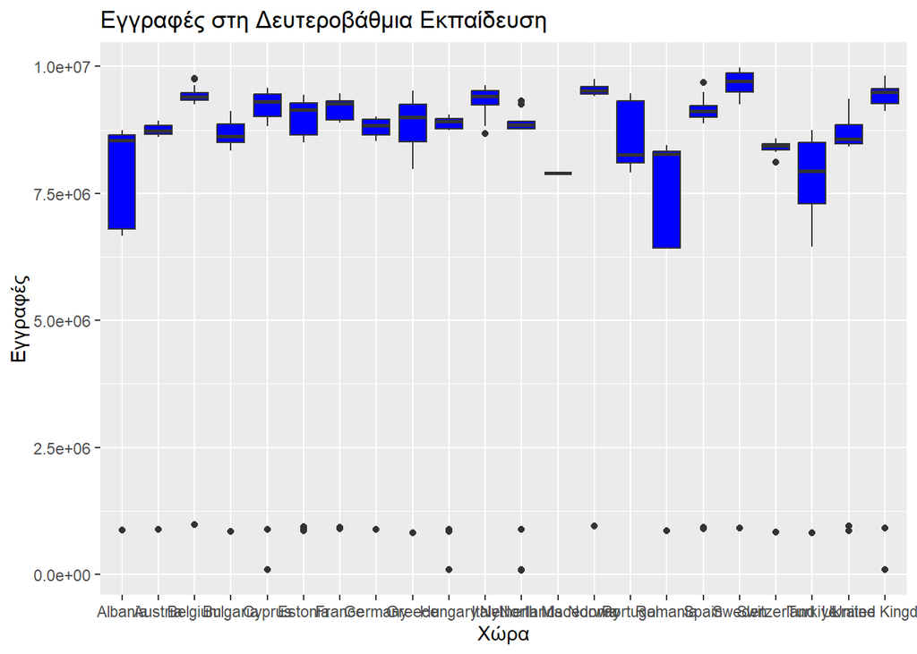

## Αναλυση Δεδομενων

Στη συνέχεια συνδικάστηκαν στοιχεία από τους διάφορους πίνακες προκειμένου να απαντηθούν τα ζητούμενα.

### Δομή Επανάληψης

Αξιοποιώντας το **Unemployment.csv** και με τη χρήση της map2 δημιουργήσαμε έναν πίνακα με το ποσοστό ανεργίας σε σχέση με τον πληθυσμό της Ελλάδας αν τα έτη. Τα αποτελέσματα παρουσιάζονται παρακάτω:

### **Ποσοστό ανεργίας στην Ελλάδα σε σχέση με τον συνολικό πληθυσμό**

```
##   Year Greece Unemployment_Rate
## 1 2000   1124      1.352588e-05
## 2 2001   1046      1.263276e-05
## 3 2002    998      4.691044e-05
## 4 2003    941      1.145071e-05
## 5 2004   1031      1.258976e-05
## 6 2005    999      1.452464e-05
```

Πληροφορίες για την συγκεκριμένη ανάλυση αντλήθηκαν από την βιβλιογραφία. [A.Ιωαννιδης (2022)](https://imegsevee.gr/wp-content/uploads/2023/04/ioannidis_apasxolisi_neon.pdf)

## Κατασκευή συναρτήσεων

Για την κατασκευή μιας συνάρτησης η οποία θα εκμεταλλεύεται έναν πίνακα του οποίου οι γραμμές θα είναι χώρες, χρησιμοποιήσαμε τον πίνακα **School_Enrollment** και υπολογίσαμε τον μέσο ορό των εγγράφων στην Δευτεροβάθμια Εκπαίδευση όπως φαίνεται παρακάτω.

```
##    2000    2001    2002    2003    2004    2005    2006    2007    2008    2009
## 7731977 6821448 8457701 7667940 9015497 8546164 7680634 8630154 8592916 8017011
##    2010    2011    2012    2013    2014    2015    2016    2017    2018    2019
## 8552001 7911560 7027482 8626482 8704195 8333278 8222650 8237355 8660827     NaN
##    2020    2021    2022
##     NaN     NaN     NaN
```

Τέλος , χρησιμοποιώντας τους πίνακες **School_Enrollment** και **Population_teen** και επιλέγοντας από τον καθένα μόνο τα δεδομένα που αφορούν την Ελλάδα δημιουργήσαμε συνάρτηση η οποία υπολογίζει την αναλογία των παιδιών που εγγράφονται στην δευτεροβάθμια εκπαίδευση σε σχέση με το συνολικό πληθυσμό των παιδιών και λάβαμε τα ακόλουθα αποτελέσματα:

### **Αναλογία εγγραφής στη Δευτεροβάθμια Εκπαίδευση σε σχέση με τον πληθυσμό των παιδιών στην Ελλάδα**

```
##          2000         2001        2002        2003        2004       2005
## 1 0.005396676 0.0005611859 0.005864181 0.005878543 0.006032659 0.06298651
##        2006        2007 2008 2009        2010 2011 2012        2013        2014
## 1 0.6288787 0.006114069   NA   NA 0.006536684   NA   NA 0.006377152 0.006247693
##          2015        2016        2017 2018 2019 2020 2021 2022
## 1 0.006356802 0.006387573 0.006474222   NA   NA   NA   NA   NA
```